# Visualização de Dados Avançada em R

# Introdução

Nessa aula veremos algumas ferramentas que R dispõe para produ??o de representações gr?ficas de informações. Vamos explorar (1) **Opções de edição no ggplot2**; (2) **Visualização Espacial**; e (3) **Mineração de Textos**. Essas visualizações são úteis para diversos conhecimentos e proporcionam um diferencial na atuação profissional, acadêmica ou pessoal. O intuito principal aqui é comunicar informação de forma **eficiente**, de modo que qualquer pessoa compreenda facilmente a mensagem que a imagem quer passar; e **agradável**, para que facilite a transmissão e recepção da mensagem.

Para visualizar a distribuição das informações vamos utilizar a base de dados do [AtlasBrasil](http://www.atlasbrasil.org.br/2013/pt/)

```r
# carregar dados
library(readxl)
AtlasBrasil <- read_excel("dados/AtlasBrasil_Consulta.xlsx")
```

[output not shown]

# Opções de Edição no ggplot2

```r
# carregar pacote
library(ggplot2)

# visualizr estrutura do tema "theme_minimal"
theme_minimal
```

```
function (base_size = 11, base_family = "")
{
    theme_bw(base_size = base_size, base_family = base_family) %+replace%
        theme(axis.ticks = element_blank(), legend.background = element_blank(),
            legend.key = element_blank(), panel.background = element_blank(),
            panel.border = element_blank(), strip.background = element_blank(),
            plot.background = element_blank(), complete = TRUE)
}
<environment: namespace:ggplot2>
```

```r
# criar um tema próprio com base no ggplot
tema_massa <- function(base_size = 12, base_family = "") {
  theme_minimal(base_size = base_size, base_family = base_family) %+replace%
    theme(axis.ticks = element_line(size = 1, colour = "grey70" ),
          axis.text.x = element_text(colour= "black",size=10,hjust=.5,vjust=.5,face="plain"),
          axis.text.y = element_text(colour="black",size=10,angle=0,hjust=1,vjust=0,face="plain"),
          axis.title.x = element_text(colour="black",size=11,angle=0,hjust=.5,vjust=0,face="plain"),
          axis.title.y = element_text(colour="black",size=11,angle=90,hjust=.5,vjust=0.5,face="plain"),
          title = element_text(colour="black",size=12,angle=0,hjust=.5,vjust=.5,face="plain"),
          panel.grid.major = element_line(colour = grey(0.85)),
          panel.grid.minor = element_line(colour = grey(1)),
          legend.key.size = unit(9, "mm"),
          legend.text = element_text(size = 9),
          legend.title = element_text(size = 9),
          axis.line = element_line(size = 1, colour = "grey70"))
}
```

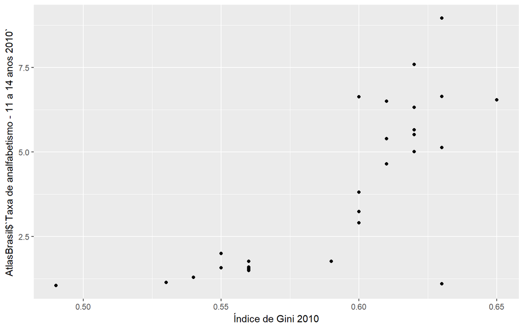

```r
# grafico scatter plot simples
ggplot(data = AtlasBrasil, aes(x =`Índice de Gini 2010`,
                               y = AtlasBrasil$`Taxa de analfabetismo - 11 a 14 anos 2010`,
                               group = 1)) +
  geom_point()
```

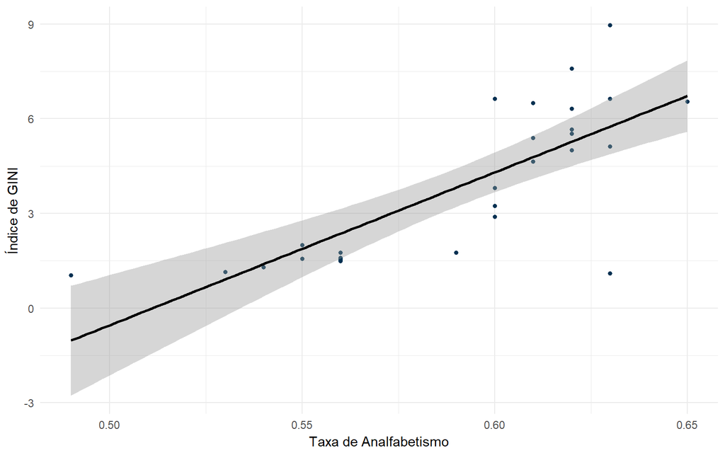

```r
# grafico scatter plot editado
ggplot(data = AtlasBrasil, aes(x =`Índice de Gini 2010`, y = AtlasBrasil$`Taxa de analfabetismo - 11 a 14 anos 2010`, group = 1)) +
  geom_point(color = "#003152", size = 1.3) +
  geom_smooth(method="lm", color = "black")+
  labs(Title = "Relação Entre Desigualdade e Analfabetismo",
       y = "Índice de GINI",
       x = "Taxa de Analfabetismo")+
  theme_minimal()
```

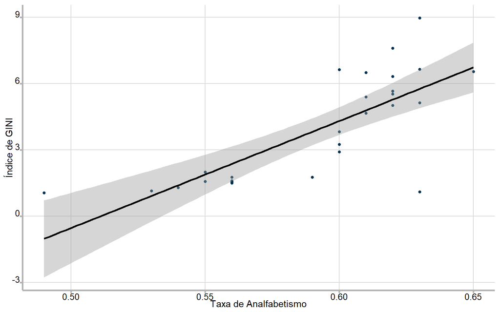

```r
# grafico scatter plot com edicao personalizada
ggplot(data = AtlasBrasil, aes(x =`Índice de Gini 2010`, y = AtlasBrasil$`Taxa de analfabetismo - 11 a 14 anos 2010`, group = 1)) +
  geom_point(color = "#003152", size = 1.3) +
  geom_smooth(method="lm", color = "black")+
  labs(Title = "Relação Entre Desigualdade e Analfabetismo",
       y = "Índice de GINI",
       x = "Taxa de Analfabetismo")+
  tema_massa()
```

# Análise Espacial em R

## Introdução

Agora vamos adentrar no mundo da visualização espacial em R. Como já sabemos, o R conta com diversos pacotes para performar uma série de análises. Aqui vamos trabalhar com alguns pacotes de manipulaçã de dados geográficos e com o pacote **ggplot2** para a visualização.

Para visualizar informações distribu?das no espaço devemos primeiro ter acesso a uma base cartográfica do espaço que queremos projetar essas informações. Por exemplo, se queremos visualizar a distruibuição da população brasileira no mapa dos estados precisamos de um arquivo com o **desenho cartográfico** do Brasil e os *polígonos* de cada Estado. Esse arquivos podem ter os formatos **.geoJSON**, **.CSV**, **.KML**, **.SHP**, entre outros.

Hoje vamos utilizar o formato **.SHP**, também chamado de **shapefile**. Acesse o link [aqui](https://github.com/claudioalvesmonteiro/municipality-inovation/tree/master/Original%20Data/Geodata) e baixe todos os arquivos com “estados_2010” para seu diretório de trabalho.

## Importando o arquivo

Para importar o arquivo instale o pacote “raster”, bem como suas dependências. Neste pacote há a função *shapefile()*, que funciona como a *read.csv()*, mas para arquivos do tipo **.SHP**.

```r
# carregar pacote
library(raster)

# carregar arquivo
shp_brasil_estados <- shapefile("dados/Geodata/estados_2010.shp")
```

## Visualização do Shape

Para produzir um gráfico espacial do tipo ggplot precisamos converter o objeto que importamos como um `SpatialPolygonsDataFrame`, uma base de dados com informações georreferenciais, para um tipo de dados `dataframe`.

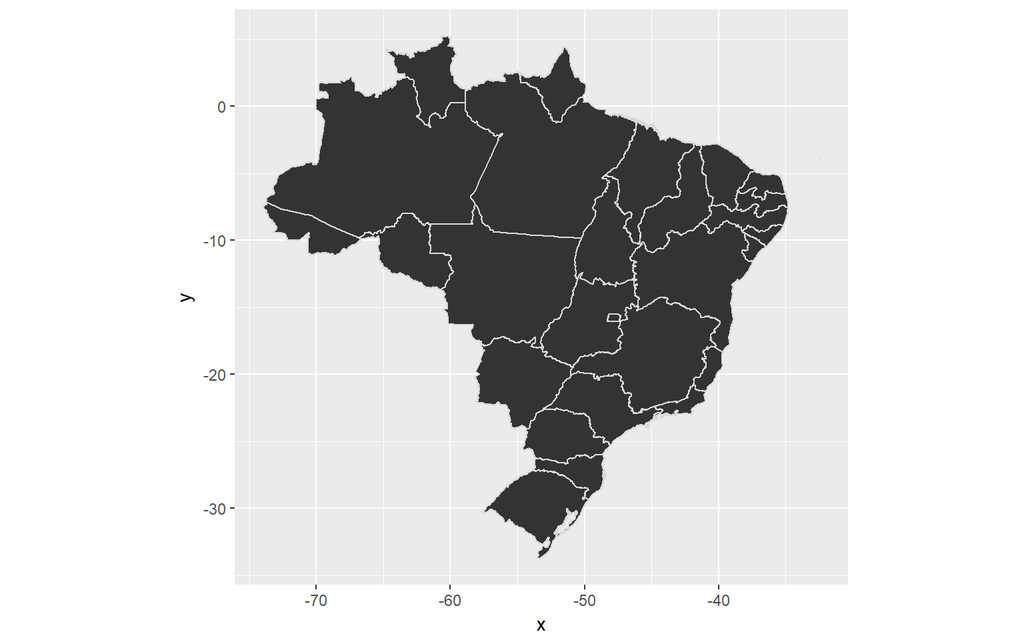

```r
# tranformar shapefile em polygonsdataframe
data_fortity <- fortify(shp_brasil_estados, region = "nome")

# produzir mapa
ggplot(data = shp_brasil_estados@data, aes(map_id = shp_brasil_estados@data$nome)) +
  geom_map(colour = grey(0.85),  map = data_fortity) +
  expand_limits(x = data_fortity$long, y = data_fortity$lat) +
  coord_fixed(1)
```

## Combinar uma base shapefile com um dataframe em R

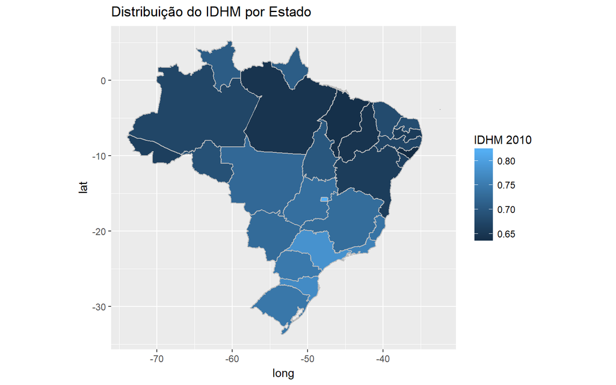

```r
# carregar pacote para manipulacao de dados
library(plyr)

# salvar informacoes da base espacial no objeto dataframe para posterior combinacao
shp_brasil_estados@data$id <- rownames(shp_brasil_estados@data)
shp_brasil_estados.df <- fortify(shp_brasil_estados)
shp_brasil_estados.df <- join(shp_brasil_estados.df, shp_brasil_estados@data, by="id")

# combinar duas bases
AtlasBrasil$codigo_ibg <- as.character(AtlasBrasil$`Código`)
shp_brasil_estados.df <- merge(shp_brasil_estados.df, AtlasBrasil, by = "codigo_ibg")

# mapa 1
ggplot(data = shp_brasil_estados.df, aes(x = long, y = lat, group = group)) +
      geom_polygon(aes(group = group, fill = `IDHM 2010`))+  # desenhar poligonos
      geom_path(color="grey")+                               # desenhar fronteiras
      labs(title = "Distribuição do IDHM por Estado")+
      coord_equal()
```

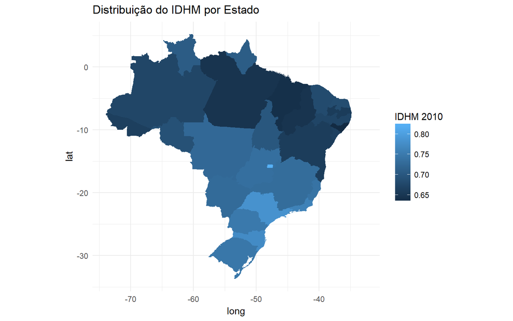

```r
# mapa 2
ggplot(data = shp_brasil_estados.df, aes(x = long, y = lat, group = group)) +
      geom_polygon(aes(group = group, fill = `IDHM 2010`))+ # desenhar poligonos
      geom_path(color=NA)+                                  # desenhar fronteiras
      labs(title = "Distribuição do IDHM por Estado")+
      coord_equal() +
      theme_minimal()
```

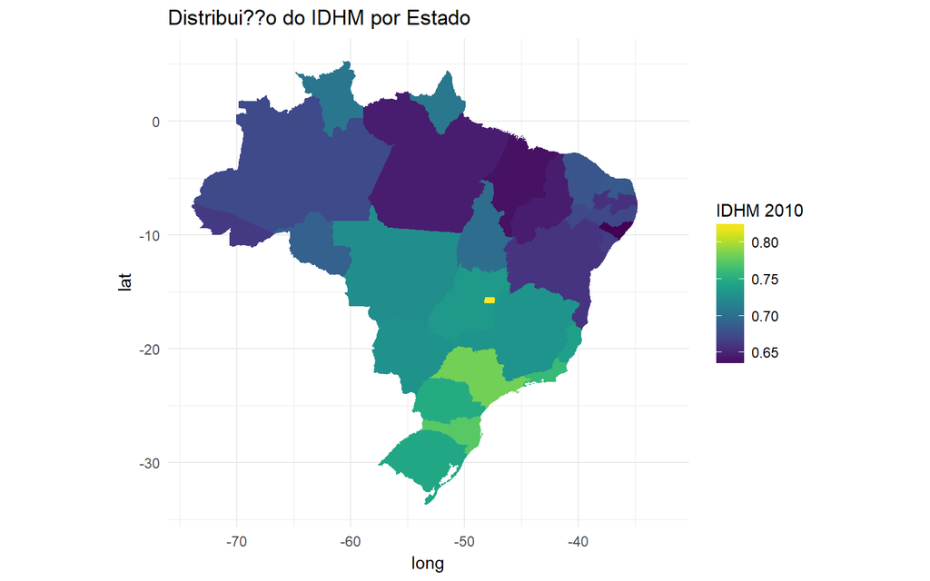

```r
# mapa 3
library(viridis)
ggplot(data = shp_brasil_estados.df, aes(x = long, y = lat, group = group)) +
      geom_polygon(aes(group = group, fill = `IDHM 2010`))+ # desenhar poligonos
      geom_path(color=NA)+                                  # desenhar fronteiras
      labs(title = "Distribui??o do IDHM por Estado")+
      coord_equal() +
      scale_fill_viridis()+
      theme_minimal()
```

# Análise/Mineração de Texto em R

## Carregar arquivos e pacotes

```r
# carregar arquivos de texto em formato .txt
alvares <- paste(readLines("dados/alvares.txt"), collapse=" ")
fernando_pessoa <- paste(readLines("dados/fernando_pessoa.txt"), collapse=" ")
mario_quintana <- paste(readLines("dados/mario_quintana.txt"), collapse=" ")

# transformar encoding dos arquivos
Encoding(alvares) <- "Latin-1"
Encoding(fernando_pessoa) <- "Latin-1"
Encoding(mario_quintana) <- "Latin-1"
```

```r
# visualizar arquivos
alvares
fernando_pessoa
mario_quintana

# instalar pacote
install.packages("tm")
```

## Tratar//padronizar textos para análise

```r
#====== criar funcao para limpar dados
clean.text <- function(x){

  library(tm)                 # carrega pacote 'tm'
  x <- tolower(x)             # transforma em caixa baixa
  x <- removePunctuation(x)   # remove pontuacao
  x <- removeNumbers(x)       # remove numeros
  x <- stripWhitespace(x)     # remove espaco em branco

  unwanted <- stopwords("pt") # remove palavras comuns em portugues
  x <- removeWords(x, unwanted)

  return(x)
}

# manipular textos com base em funcao criada
Alvares   <- clean.text(alvares)
Fernando  <- clean.text(fernando_pessoa)
Mario     <- clean.text(mario_quintana)
```

## Mineração

```r
# instalar pacote
library(qdap)

# analisar termos mais frequentes em cada autor
freq_alvares <- freq_terms(Alvares, Inf, at.least = 3)
freq_fernando <- freq_terms(Fernando, Inf, at.least = 3)
freq_mario <- freq_terms(Mario, Inf, at.least = 3)

# selecionar as 15 palavras mais citadas
freq_alvares15  <- freq_alvares[1:15,]
freq_fernando <- freq_fernando[1:15,]
freq_mario    <- freq_mario[1:15,]
```

## Visualização

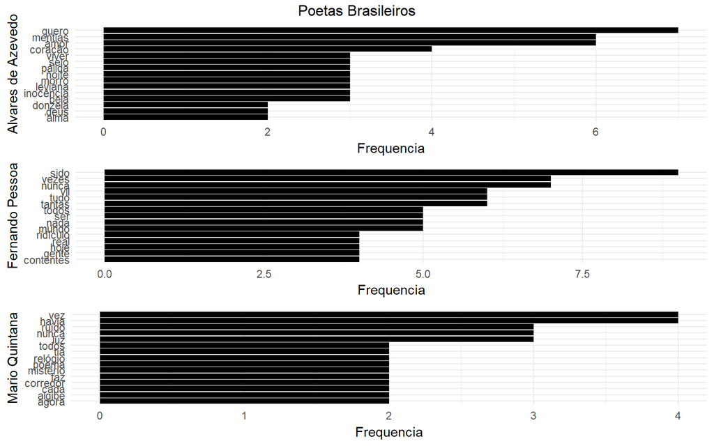

```r
# Alvares de Azevedo #
p1  <- ggplot(freq_alvares15, aes(x = reorder(freq_alvares15$WORD, + freq_alvares15$FREQ), y = freq_alvares15$FREQ)) +
  geom_bar(stat = "identity", fill = "black") +
  theme(panel.background = element_rect(fill = 'white'))+
  labs(x = "Alvares de Azevedo", y = "Frequencia" )+
  theme_minimal()+
  coord_flip()

# Fernando Pessoa #
p2  <- ggplot(freq_fernando, aes(x = reorder(freq_fernando$WORD, + freq_fernando$FREQ), y = freq_fernando$FREQ)) +   geom_bar(stat = "identity", fill = "black") +
  theme(panel.background = element_rect(fill = 'white'))+
  labs(x = "Fernando Pessoa", y = "Frequencia" )+
  theme_minimal()+
  coord_flip()

# Mario Quintana #
p3  <- ggplot(freq_mario, aes(x = reorder(freq_mario$WORD, + freq_mario$FREQ), y = freq_mario$FREQ)) +
  geom_bar(stat = "identity", fill = "black") +
  theme(panel.background = element_rect(fill = 'white'))+
  labs(x = "Mario Quintana", y = "Frequencia" )+
  theme_minimal()+
  coord_flip()

#===== Grafico comparativo   #
library(gridExtra)
grid.arrange(p1, p2, p3, top = "Poetas Brasileiros")
```

## Nuvem de Palavras (Wordcloud)

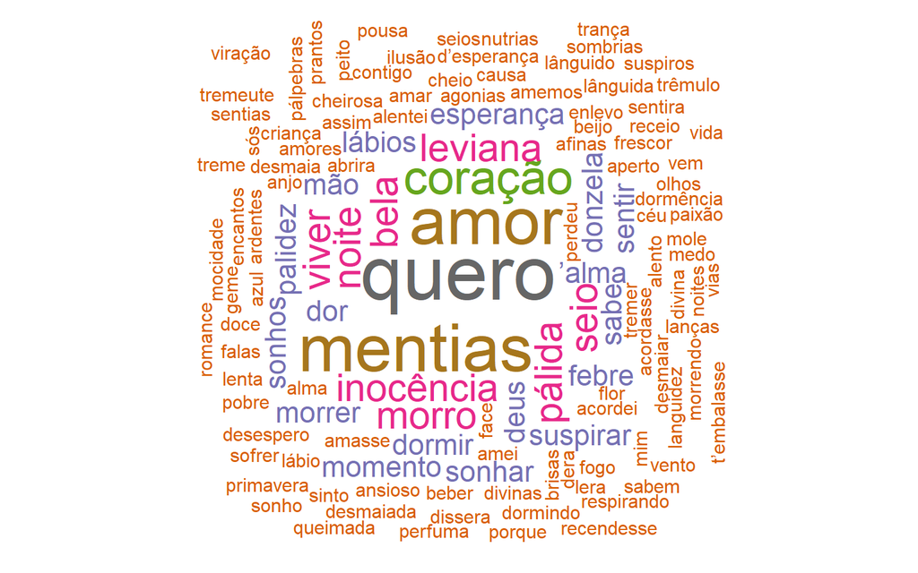

```r
# carregar pacote e executar wordcloud
library(wordcloud)

wordcloud(words = freq_alvares$WORD, freq = freq_alvares$FREQ, min.freq = 1,
          max.words=200, random.order=FALSE, rot.per=0.35,
          colors=brewer.pal(8, "Dark2"))
```

Cláudio A. Monteiro

Novembro, 2018